# Understanding Standardization and SMD

Causal Inference Course

2026-01-28

# Introduction

This tutorial explains standardization from first principles, building up to the Standardized Mean Difference (SMD) used in propensity score matching.

## Topics Covered

1. What is standardization? (z-scores)
2. Manual calculation with for loops
3. Using built-in functions (scale())
4. Why standardize? (comparing apples to oranges)
5. Pooled standard deviation
6. Standardized Mean Difference (SMD)
7. SMD vs Statistical Significance

# Part 1: What is Standardization?

## 1.1 The Problem: Variables Have Different Scales

Imagine we have data on people with very different measurement scales:

```r
age <- c(25, 30, 35, 40, 45, 50, 55, 60)       # Age in years (range: 25-60)
income <- c(30, 45, 55, 70, 80, 95, 110, 150)  # Income in thousands (range: 30-150)
```

| Variable | Values |
| --- | --- |
| Age (years) | 25, 30, 35, 40, 45, 50, 55, 60 |
| Income (thousands) | 30, 45, 55, 70, 80, 95, 110, 150 |

**The Problem:**

- Age ranges from 25 to 60 (spread of 35)
- Income ranges from 30 to 150 (spread of 120)
- Is a difference of 10 years “the same” as $10k?
- **We need a common scale!**

## 1.2 The Solution: Z-scores (Standardization)

Standardization converts any variable to a common scale:

- Mean becomes **0**
- Standard deviation becomes **1**
- Values are now in “standard deviation units”

### The Formula

$$z = \frac{\text{value} -
\text{mean}}{\text{standard deviation}}$$

### Interpretation of Z-scores

| Z-score | Interpretation |
| --- | --- |
| z = 0 | Exactly average |
| z = 1 | 1 standard deviation above average |
| z = -1 | 1 standard deviation below average |
| z = 2 | 2 standard deviations above average (unusual) |
| z = -2 | 2 standard deviations below average (unusual) |

# Part 2: Manual Calculation with For Loops

## 2.1 Step 1: Calculate the Mean

```r
n <- length(age)
sumAge <- 0

for (i in 1:n) {
  sumAge <- sumAge + age[i]
}

meanAge <- sumAge / n
```

Calculating mean of age manually:

- Sum of all values: 340
- Number of values: 8
- Mean = Sum / N = 340 / 8 = **42.5**

Verification with `mean()`: 42.5 ✓

## 2.2 Step 2: Calculate the Standard Deviation

Standard deviation measures how spread out the data is.

$$SD = \sqrt{\frac{\sum(x -
\text{mean})^2}{n - 1}}$$

```r
sumSquaredDev <- 0

cat("Calculating squared deviations from mean:\n")
```

```
## Calculating squared deviations from mean:
```

```r
for (i in 1:n) {
  deviation <- age[i] - meanAge
  squaredDev <- deviation^2
  sumSquaredDev <- sumSquaredDev + squaredDev

  cat("  age[", i, "] =", age[i],
      ", deviation =", round(deviation, 2),
      ", squared =", round(squaredDev, 2), "\n")
}
```

```
##   age[ 1 ] = 25 , deviation = -17.5 , squared = 306.25
##   age[ 2 ] = 30 , deviation = -12.5 , squared = 156.25
##   age[ 3 ] = 35 , deviation = -7.5 , squared = 56.25
##   age[ 4 ] = 40 , deviation = -2.5 , squared = 6.25
##   age[ 5 ] = 45 , deviation = 2.5 , squared = 6.25
##   age[ 6 ] = 50 , deviation = 7.5 , squared = 56.25
##   age[ 7 ] = 55 , deviation = 12.5 , squared = 156.25
##   age[ 8 ] = 60 , deviation = 17.5 , squared = 306.25
```

```r
variance <- sumSquaredDev / (n - 1)  # Note: n-1 for sample variance
sdAge <- sqrt(variance)
```

- Sum of squared deviations: 1050
- Variance = Sum / (n-1) = 1050 / 7 = 150
- SD = sqrt(Variance) = sqrt(150) = **12.25**

Verification with `sd()`: 12.25 ✓

## 2.3 Step 3: Calculate Z-scores for Each Value

```r
zAge <- numeric(n)

cat("Applying z-score formula: z = (value - mean) / SD\n")
```

```
## Applying z-score formula: z = (value - mean) / SD
```

```r
cat("Mean =", meanAge, ", SD =", round(sdAge, 2), "\n\n")
```

```
## Mean = 42.5 , SD = 12.25
```

```r
for (i in 1:n) {
  zAge[i] <- (age[i] - meanAge) / sdAge

  cat("  age[", i, "] =", age[i],
      ": z = (", age[i], "-", meanAge, ") /", round(sdAge, 2),
      "=", round(zAge[i], 3), "\n")
}
```

```
##   age[ 1 ] = 25 : z = ( 25 - 42.5 ) / 12.25 = -1.429
##   age[ 2 ] = 30 : z = ( 30 - 42.5 ) / 12.25 = -1.021
##   age[ 3 ] = 35 : z = ( 35 - 42.5 ) / 12.25 = -0.612
##   age[ 4 ] = 40 : z = ( 40 - 42.5 ) / 12.25 = -0.204
##   age[ 5 ] = 45 : z = ( 45 - 42.5 ) / 12.25 = 0.204
##   age[ 6 ] = 50 : z = ( 50 - 42.5 ) / 12.25 = 0.612
##   age[ 7 ] = 55 : z = ( 55 - 42.5 ) / 12.25 = 1.021
##   age[ 8 ] = 60 : z = ( 60 - 42.5 ) / 12.25 = 1.429
```

| Original ages | 25, 30, 35, 40, 45, 50, 55, 60 |
| --- | --- |
| Standardized (z) | -1.429, -1.021, -0.612, -0.204, 0.204, 0.612, 1.021, 1.429 |

### Verifying Z-score Properties

```r
mean_z <- mean(zAge)
sd_z <- sd(zAge)
```

- Mean of z-scores: 0 (should be ~0) ✓
- SD of z-scores: 1 (should be ~1) ✓

# Part 3: Using Built-in Functions

## 3.1 The `scale()` Function

R’s `scale()` function does standardization automatically:

```r
zAgeBuiltin <- scale(age)
```

| Method | Result |
| --- | --- |
| Using `scale(age)` | -1.429, -1.021, -0.612, -0.204, 0.204, 0.612, 1.021, 1.429 |
| Manual calculation | -1.429, -1.021, -0.612, -0.204, 0.204, 0.612, 1.021, 1.429 |

Maximum difference: 0 ✓

## 3.2 Standardizing Multiple Variables

```r
df <- data.frame(age = age, income = income)

# Standardize both columns
dfStd <- as.data.frame(scale(df))
```

**Original data:**

| age | income |
| --- | --- |
| 25 | 30 |
| 30 | 45 |
| 35 | 55 |
| 40 | 70 |
| 45 | 80 |
| 50 | 95 |
| 55 | 110 |
| 60 | 150 |

**Standardized data:**

| age | income |
| --- | --- |
| -1.429 | -1.277 |
| -1.021 | -0.889 |
| -0.612 | -0.630 |
| -0.204 | -0.242 |
| 0.204 | 0.016 |
| 0.612 | 0.404 |
| 1.021 | 0.792 |
| 1.429 | 1.826 |

Now both variables are on the same scale! We can directly compare: a z-score of 1.5 means the same thing for both age and income (1.5 SDs above average).

# Part 4: Why Standardize? (Visual Demonstration)

```r
set.seed(456)
n_large <- 200

# Generate data with very different scales
height_cm <- rnorm(n_large, mean = 170, sd = 10)    # Height: 150-190 cm
weight_kg <- rnorm(n_large, mean = 70, sd = 15)     # Weight: 40-100 kg
salary_k <- rnorm(n_large, mean = 50, sd = 20)      # Salary: 10-90 thousand
```

## Before Standardization

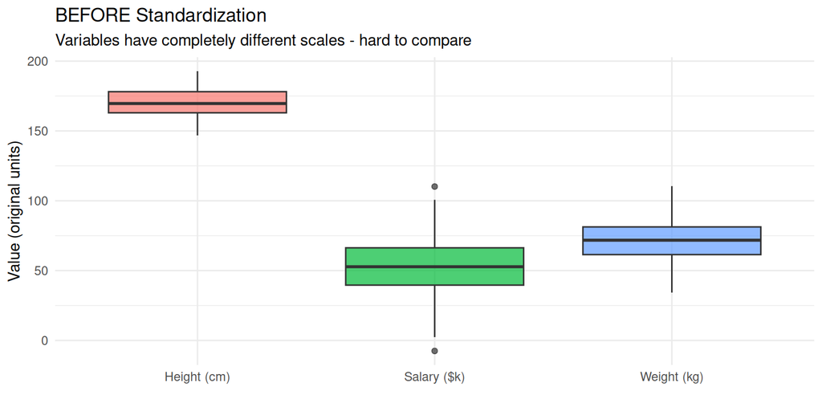

```r
plotDataBefore <- data.frame(
  value = c(height_cm, weight_kg, salary_k),
  variable = rep(c("Height (cm)", "Weight (kg)", "Salary ($k)"), each = n_large)
)

ggplot(plotDataBefore, aes(x = variable, y = value, fill = variable)) +
  geom_boxplot(alpha = 0.7) +
  labs(title = "BEFORE Standardization",
       subtitle = "Variables have completely different scales - hard to compare",
       x = "", y = "Value (original units)") +
  theme_minimal() +
  theme(legend.position = "none")
```

## After Standardization

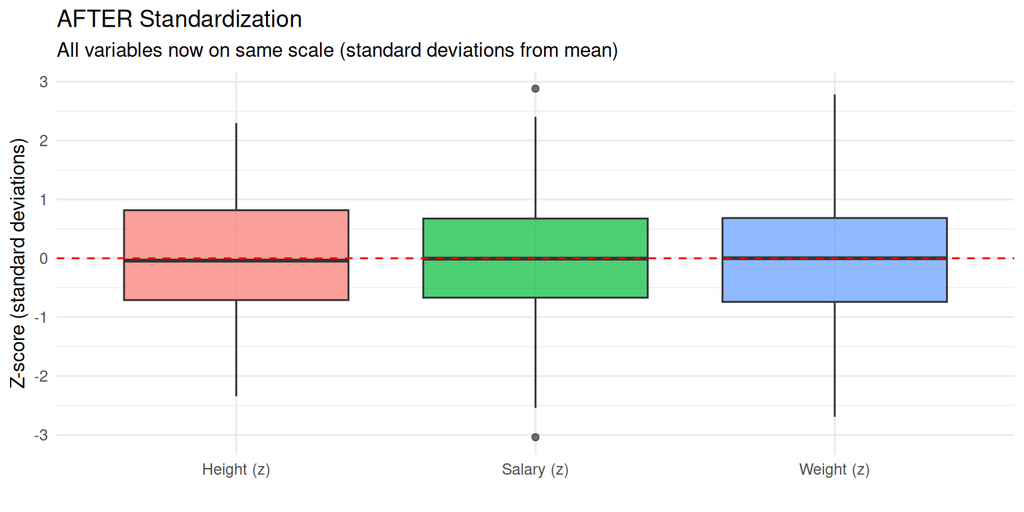

```r
height_z <- scale(height_cm)
weight_z <- scale(weight_kg)
salary_z <- scale(salary_k)

plotDataAfter <- data.frame(
  value = c(height_z, weight_z, salary_z),
  variable = rep(c("Height (z)", "Weight (z)", "Salary (z)"), each = n_large)
)

ggplot(plotDataAfter, aes(x = variable, y = value, fill = variable)) +
  geom_boxplot(alpha = 0.7) +
  labs(title = "AFTER Standardization",
       subtitle = "All variables now on same scale (standard deviations from mean)",
       x = "", y = "Z-score (standard deviations)") +
  theme_minimal() +
  theme(legend.position = "none") +
  geom_hline(yintercept = 0, linetype = "dashed", color = "red")
```

**After standardization:**

- All variables have mean = 0 and SD = 1
- We can now compare “apples to oranges”
- A person with z = 2 for height is equally unusual as z = 2 for salary

# Part 5: Pooled Standard Deviation

## 5.1 The Problem: Two Groups with Different SDs

```r
set.seed(789)
group1 <- rnorm(50, mean = 100, sd = 10)  # Less variable
group2 <- rnorm(50, mean = 110, sd = 20)  # More variable
```

| Group | Mean | SD |
| --- | --- | --- |
| School 1 | 98.55 | 9.21 |
| School 2 | 111.36 | 20.55 |

**Question:** How different are these groups?

**Problem:** They have different SDs. Which SD should we use to standardize?

## 5.2 Solution: Pooled Standard Deviation

Pooled SD combines the variability from both groups. It’s like asking: “What’s the typical spread across both groups combined?”

### Formula (equal group sizes)

$$\text{Pooled SD} = \sqrt{\frac{SD_1^2 +
SD_2^2}{2}}$$

```r
sd1 <- sd(group1)
sd2 <- sd(group2)

pooledSD <- sqrt((sd1^2 + sd2^2) / 2)
```

| Component | Value |
| --- | --- |
| SD₁ | 9.21 |
| SD₁² | 84.87 |
| SD₂ | 20.55 |
| SD₂² | 422.24 |
| Average of variances | 253.55 |
| **Pooled SD** | **15.92** |

Note: Pooled SD (15.92) is between SD₁ (9.21) and SD₂ (20.55)

## 5.3 Why Not Just Average the SDs?

```r
simpleAvg <- (sd1 + sd2) / 2
```

| Method | Value |
| --- | --- |
| Simple average: (SD₁ + SD₂) / 2 | 14.88 |
| Pooled SD | 15.92 |

They’re different! Why use pooled SD?

- **Variance (SD²) is additive**, SD is not
- Pooled SD properly accounts for the spread in each group
- It’s the mathematically correct way to combine variability

# Part 6: Standardized Mean Difference (SMD)

## 6.1 What is SMD?

SMD measures how different two groups are, **in standard deviation units**.

### Formula

$$SMD = \frac{\text{Mean(Group 1)} -
\text{Mean(Group 2)}}{\text{Pooled SD}}$$

### Interpretation

| SMD | Interpretation |
| --- | --- |
| 0 | Groups have identical means |
| 0.2 | Small difference (0.2 SDs apart) |
| 0.5 | Medium difference (0.5 SDs apart) |
| 0.8 | Large difference (0.8 SDs apart) |
| 1.0 | Very large (the means are 1 full SD apart) |

## 6.2 Manual SMD Calculation

```r
mean1 <- mean(group1)
mean2 <- mean(group2)
meanDiff <- mean1 - mean2

smd <- meanDiff / pooledSD
```

Using our school example:

|  | Value |
| --- | --- |
| Mean(School 1) | 98.55 |
| Mean(School 2) | 111.36 |
| Difference | -12.8 |
| Pooled SD | 15.92 |
| **SMD** | **-0.804** |

Interpretation: The schools differ by **0.8 standard deviations**.

```
## This is a LARGE difference.
```

## 6.3 Creating a Reusable SMD Function

```r
calcSMD <- function(x, groupIndicator) {
  # x: the variable to compare
  # groupIndicator: 0/1 indicator for which group each observation belongs to

  # Step 1: Calculate means for each group
  mean1 <- mean(x[groupIndicator == 1])
  mean0 <- mean(x[groupIndicator == 0])

  # Step 2: Calculate SDs for each group
  sd1 <- sd(x[groupIndicator == 1])
  sd0 <- sd(x[groupIndicator == 0])

  # Step 3: Calculate pooled SD
  pooledSD <- sqrt((sd1^2 + sd0^2) / 2)

  # Step 4: Calculate SMD
  smd <- (mean1 - mean0) / pooledSD

  return(smd)
}
```

## 6.4 SMD in Propensity Score Matching

```r
set.seed(123)
n_obs <- 200

# Confounded data: treatment depends on age
age_sim <- rnorm(n_obs, mean = 40, sd = 10)
treat_prob <- plogis(-2 + 0.05 * age_sim)  # Higher age -> more likely treated
treatment <- rbinom(n_obs, 1, treat_prob)

smd_age <- calcSMD(age_sim, treatment)
```

In propensity score matching, we use SMD to check **BALANCE**.

| Group | Mean Age |
| --- | --- |
| Treated | 41.13 |
| Control | 38.65 |
| **SMD** | **0.264** |

### Balance Thresholds

| SMD | Interpretation |
| --- | --- |
| \|SMD\| < 0.1 | Good balance (groups are similar) |
| \|SMD\| < 0.25 | Acceptable balance |
| \|SMD\| > 0.25 | Poor balance (groups are too different) |

```
## With SMD = 0.264 , we have POOR balance.
## This means age is confounded with treatment.
## We need matching to fix this!
```

# Part 7: Visual Summary - What Different SMDs Look Like

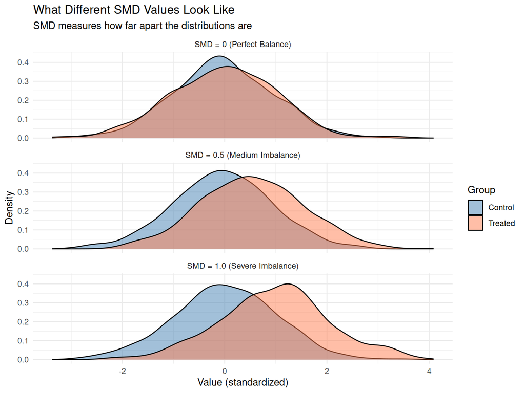

```r
set.seed(42)
n_demo <- 500

smd_examples <- data.frame(
  value = c(
    rnorm(n_demo, mean = 0, sd = 1),    # Control (SMD = 0)
    rnorm(n_demo, mean = 0, sd = 1),    # Treatment group 1
    rnorm(n_demo, mean = 0, sd = 1),    # Control (SMD = 0.5)
    rnorm(n_demo, mean = 0.5, sd = 1),  # Treatment group 2
    rnorm(n_demo, mean = 0, sd = 1),    # Control (SMD = 1.0)
    rnorm(n_demo, mean = 1.0, sd = 1)   # Treatment group 3
  ),
  group = rep(c("Control", "Treated"), times = 3, each = n_demo),
  scenario = rep(c("SMD = 0 (Perfect Balance)",
                   "SMD = 0.5 (Medium Imbalance)",
                   "SMD = 1.0 (Severe Imbalance)"), each = 2 * n_demo)
)

ggplot(smd_examples, aes(x = value, fill = group)) +
  geom_density(alpha = 0.5) +
  facet_wrap(~ scenario, ncol = 1) +
  scale_fill_manual(values = c("Control" = "steelblue", "Treated" = "coral")) +
  labs(title = "What Different SMD Values Look Like",
       subtitle = "SMD measures how far apart the distributions are",
       x = "Value (standardized)", y = "Density",
       fill = "Group") +
  theme_minimal()
```

# Part 8: SMD vs Statistical Significance

> **IMPORTANT:** SMD is NOT the same as statistical significance!

## 8.1 What SMD Actually Tells You

SMD tells you **HOW DIFFERENT** two groups are, measured in standard deviations.

Think of it as “overlap” between distributions:

| SMD | Overlap | % of Treated Above Control Mean |
| --- | --- | --- |
| 0.0 | Complete overlap | 50% |
| 0.5 | Moderate overlap | ~69% |
| 1.0 | Little overlap | ~84% |
| 2.0 | Almost no overlap | ~97.7% |

## 8.2 The Key Difference: SMD vs P-values

|  | SMD | P-value |
| --- | --- | --- |
| Depends on sample size? | **NO** | YES |
| What it measures | Effect SIZE | Probability under null |
| With n=10,000 | Same SMD | Tiny p-value |
| With n=10 | Same SMD | Large p-value |

**The relationship:**
$$t\text{-statistic} \approx SMD \times
\sqrt{\frac{n}{2}}$$

```r
set.seed(999)

# Small sample
n_small <- 20
g1_small <- rnorm(n_small/2, mean = 0, sd = 1)
g2_small <- rnorm(n_small/2, mean = 0.5, sd = 1)
smd_small <- (mean(g2_small) - mean(g1_small)) / sqrt((sd(g1_small)^2 + sd(g2_small)^2) / 2)
ttest_small <- t.test(g2_small, g1_small)

# Medium sample
n_med <- 100
g1_med <- rnorm(n_med/2, mean = 0, sd = 1)
g2_med <- rnorm(n_med/2, mean = 0.5, sd = 1)
smd_med <- (mean(g2_med) - mean(g1_med)) / sqrt((sd(g1_med)^2 + sd(g2_med)^2) / 2)
ttest_med <- t.test(g2_med, g1_med)

# Large sample
n_large <- 1000
g1_large <- rnorm(n_large/2, mean = 0, sd = 1)
g2_large <- rnorm(n_large/2, mean = 0.5, sd = 1)
smd_large <- (mean(g2_large) - mean(g1_large)) / sqrt((sd(g1_large)^2 + sd(g2_large)^2) / 2)
ttest_large <- t.test(g2_large, g1_large)
```

[output not shown]

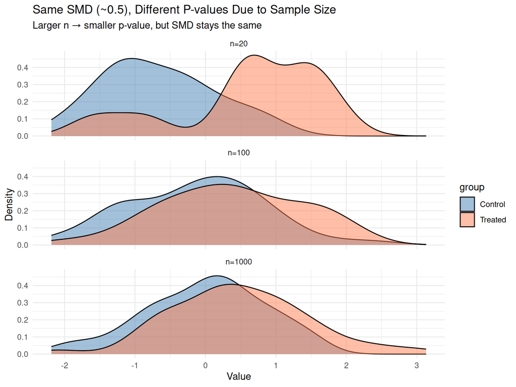

```r
vizSmall <- data.frame(value = c(g1_small, g2_small),
                       group = rep(c("Control", "Treated"), each = n_small/2),
                       sample = "n=20")
vizMed <- data.frame(value = c(g1_med, g2_med),
                     group = rep(c("Control", "Treated"), each = n_med/2),
                     sample = "n=100")
vizLarge <- data.frame(value = c(g1_large[1:100], g2_large[1:100]),
                       group = rep(c("Control", "Treated"), each = 100),
                       sample = "n=1000")

vizData <- rbind(vizSmall, vizMed, vizLarge)
vizData$sample <- factor(vizData$sample, levels = c("n=20", "n=100", "n=1000"))

ggplot(vizData, aes(x = value, fill = group)) +
  geom_density(alpha = 0.5) +
  facet_wrap(~ sample, ncol = 1) +
  scale_fill_manual(values = c("Control" = "steelblue", "Treated" = "coral")) +
  labs(title = "Same SMD (~0.5), Different P-values Due to Sample Size",
       subtitle = "Larger n → smaller p-value, but SMD stays the same",
       x = "Value", y = "Density") +
  theme_minimal()
```

## 8.4 Why We Use SMD for Balance (Not P-values)

In propensity score matching, we check BALANCE using **SMD**, not p-values.

**Why?**

1. **P-values are confounded by sample size**
   - Large studies show “significant” imbalance even for tiny differences
   - Small studies might miss substantial imbalance
2. **SMD tells you the PRACTICAL importance of imbalance**
   - SMD = 0.01 is trivial, even if p < 0.001 with large n
   - SMD = 0.50 is substantial, even if p > 0.05 with small n
3. **SMD has intuitive thresholds that don’t change with sample size**
   - |SMD| < 0.1: Good balance (groups practically identical)
   - |SMD| < 0.25: Acceptable balance
   - |SMD| > 0.25: Poor balance (confounding likely)

## 8.5 The Bottom Line

| Question | Use This |
| --- | --- |
| “How different are these groups?” | **SMD** |
| “Could this difference be due to chance?” | P-value |

For **BALANCE assessment** in matching:

- ✅ **USE SMD** - it tells you if groups are practically similar
- ❌ **DON’T rely on p-values** - they’ll mislead you with large samples

# Part 9: Can We Standardize Categorical Variables?

This is an important question! Not all variables can be standardized.

## 9.1 Types of Categorical Variables

Categorical variables come in two main types:

**1. NOMINAL (no natural order):**

- Colors: red, blue, green
- Country: USA, France, Japan
- Gender: male, female, other
- Major: economics, political science, engineering

**2. ORDINAL (natural order exists):**

- Education: high school < bachelor’s < master’s < PhD
- Satisfaction: very dissatisfied < dissatisfied < neutral < satisfied < very satisfied
- Income bracket: low < medium < high
- Pain level: none < mild < moderate < severe

## 9.2 Why NOMINAL Variables CANNOT Be Standardized

Standardization requires:

$$z = \frac{\text{value} -
\text{mean}}{SD}$$

For this formula to make sense, you need:

1. **Meaningful arithmetic** (can you subtract ‘blue’ from ‘red’?)
2. **A meaningful mean** (what’s the ‘average’ of red, blue, green?)
3. **A meaningful distance** (is blue ‘2 units’ from red?)

**Example: Favorite color**

- If we code: red=1, blue=2, green=3
- Mean = 2 (blue?) - this is **MEANINGLESS!**
- The numbers are just arbitrary labels
- Changing to red=5, blue=10, green=15 would give different ‘z-scores’

> **CONCLUSION:** You **CANNOT** standardize nominal variables. The numbers assigned to categories are arbitrary.

## 9.3 Can ORDINAL Variables Be Standardized?

Ordinal variables have **ORDER** but not equal **INTERVALS**.

**Example: Education level**

- High school (1) < Bachelor’s (2) < Master’s (3) < PhD (4)
- We know 4 > 3 > 2 > 1
- But is the ‘gap’ from HS to Bachelor’s the same as Master’s to PhD?
- Probably not! These intervals are NOT necessarily equal.

**The problem:**

- Standardization assumes equal intervals
- z = 1 means ‘1 SD above mean’
- This assumes moving 1 unit anywhere on the scale means the same thing

**IN PRACTICE (with caution):**

- Many researchers DO standardize ordinal variables
- Especially with many categories (e.g., Likert 1-7)
- It’s an approximation that often works reasonably well
- But be aware of the assumption being made!

## 9.4 What To Do Instead for Categorical Variables

**For NOMINAL variables in balance checking:**

- Compare PROPORTIONS in each category between groups
- Use chi-squared test for overall difference
- Report percentage in each category by treatment group

**For BINARY variables (special case of nominal):**

SMD **CAN** be calculated for binary variables!

$$SMD_{binary} = \frac{p_1 -
p_0}{\sqrt{p(1-p)}}$$

Where $p_1$, $p_0$ are proportions in each group and $p$ is the pooled proportion.

```r
set.seed(456)
n_demo <- 200

# Create confounded treatment assignment based on a binary variable
is_stem <- rbinom(n_demo, 1, 0.4)  # 40% are STEM majors
treat_prob <- 0.3 + 0.4 * is_stem  # STEM more likely to be treated
treatment <- rbinom(n_demo, 1, treat_prob)

# Calculate proportions
p1 <- mean(is_stem[treatment == 1])  # Proportion STEM in treated
p0 <- mean(is_stem[treatment == 0])  # Proportion STEM in control
p_pooled <- mean(is_stem)

# SMD for binary variable
smd_binary <- (p1 - p0) / sqrt(p_pooled * (1 - p_pooled))

binary_balance <- data.frame(
  Group = c("Treated", "Control", "Difference"),
  Proportion_STEM = c(round(p1, 3), round(p0, 3), round(p1 - p0, 3)),
  SMD = c("-", "-", round(smd_binary, 3))
)
kable(binary_balance)
```

| Group | Proportion_STEM | SMD |
| --- | --- | --- |
| Treated | 0.677 | - |
| Control | 0.231 | - |
| Difference | 0.446 | 0.898 |

The SMD of 0.898 tells us STEM majors are overrepresented in the treated group (imbalance that needs fixing).

## 9.5 Summary: What Can Be Standardized?

```r
summary_table <- data.frame(
  Variable_Type = c("Continuous", "Binary (0/1)", "Ordinal", "Nominal"),
  Can_Standardize = c("YES", "YES (modified)", "MAYBE (with caution)", "NO"),
  Notes = c("Standard z-score formula",
            "Use proportion-based SMD formula",
            "Assumes equal intervals (often violated)",
            "No meaningful arithmetic on categories")
)
kable(summary_table, col.names = c("Variable Type", "Can Standardize?", "Notes"))
```

| Variable Type | Can Standardize? | Notes |
| --- | --- | --- |
| Continuous | YES | Standard z-score formula |
| Binary (0/1) | YES (modified) | Use proportion-based SMD formula |
| Ordinal | MAYBE (with caution) | Assumes equal intervals (often violated) |
| Nominal | NO | No meaningful arithmetic on categories |

**KEY TAKEAWAY:**

- **Continuous & binary:** Standardize and use SMD
- **Ordinal:** Can approximate, but interpret carefully
- **Nominal:** Cannot standardize - compare proportions instead

# Summary: Key Concepts

## 1. Standardization (Z-score)

- Converts any variable to mean=0, SD=1
- Formula: $z = \frac{\text{value} - \text{mean}}{SD}$
- Allows comparing variables with different scales

## 2. Pooled Standard Deviation

- Combines variability from two groups
- Formula: $\text{pooled SD} = \sqrt{\frac{SD_1^2 + SD_2^2}{2}}$
- Used when groups have different spreads

## 3. Standardized Mean Difference (SMD)

- Measures group difference in SD units
- Formula: $SMD = \frac{\text{mean}_1 - \text{mean}_2}{\text{pooled SD}}$
- Thresholds: <0.1 good, <0.25 acceptable, >0.25 poor

## 4. Why SMD Matters for Matching

- Before matching: SMD shows imbalance (confounding)
- After matching: SMD should decrease (balance improved)
- Goal: |SMD| < 0.1 for all covariates

## 5. SMD vs P-values

- SMD is **effect size** (independent of sample size)
- P-values depend heavily on sample size
- Use SMD, not p-values, for balance assessment

## 6. Categorical Variables

- **Nominal:** Cannot standardize (no meaningful arithmetic)
- **Binary:** Can calculate SMD using proportion-based formula
- **Ordinal:** Can approximate with caution (assumes equal intervals)